# Beerio Statistics

Updated: Mar 16, 2020

This document tracks Beerio game statistics. The last tracked games were 4 games played on Monday, March 16, 2020 by Neil, Chuck, and Steve.

# All Game Data

This table contains scores and events for all logged games. It is searchable and sortable on all columns.

| Date | Game | Chuck | Neil | Shawn | Steve | Punishment | date_dummy |
| --- | --- | --- | --- | --- | --- | --- | --- |
| Monday, March 16, 2020 | 1 | 24 | 44 |  | 25 |  | 2020-03-16 |
| Monday, March 16, 2020 | 2 | 21 | 31 |  | 18 |  | 2020-03-16 |
| Monday, March 16, 2020 | 3 | 19 | 44 |  | 19 |  | 2020-03-16 |
| Monday, March 16, 2020 | 4 | 19 | 33 |  | 14 |  | 2020-03-16 |
| Saturday, March 14, 2020 | 1 | 16 | 28 | 16 | 24 |  | 2020-03-14 |
| Saturday, March 14, 2020 | 2 | 27 | 30 | 14 | 20 |  | 2020-03-14 |
| Saturday, March 14, 2020 | 3 | 19 | 25 | 15 | 11 |  | 2020-03-14 |
| Saturday, March 14, 2020 | 4 | 18 | 35 | 20 | 16 |  | 2020-03-14 |
| Saturday, March 14, 2020 | 5 | 19 | 39 |  | 18 |  | 2020-03-14 |
| Saturday, March 14, 2020 | 6 | 29 | 21 |  |  |  | 2020-03-14 |

[output cut: 40 more lines]

# Descriptive Statistics

This table depicts overall Beerio statistics for all tracked players. Recent Average is calculated as the average score from the last date the player played.

| Name | GamesPlayed | Victories | WinPercentage | OverallAverage | RecentAverage | BestScore | WorstScore | TimesPunished | TimesPunisher |
| --- | --- | --- | --- | --- | --- | --- | --- | --- | --- |
| Chuck | 39 | 6 | 0.15 | 21.6 | 20.8 | 34 | 11 | 2 | 1 |
| Neil | 47 | 37 | 0.79 | 29.9 | 38 | 48 | 16 | 1 | 2 |
| Shawn | 24 | 5 | 0.21 | 24.5 | 16.2 | 37 | 14 | 1 | 0 |
| Steve | 25 | 0 | 0 | 18.9 | 19 | 28 | 8 | 2 | 0 |

# Figures

The first figure depicts Beerio scores over games in each day. Punishments are indicated by a blue shell. Days with only one game are excluded.

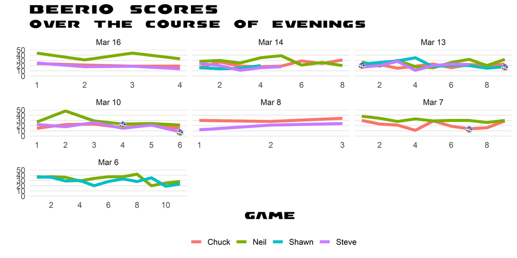

The next plot pools the data across evenings to show the change in average score for each player as the evening wears on. Points indicate scores for each match, jittered horizontally to reduce overplotting. In a linear model, each additional game is associated with a score difference of -0.44 (95% CI: -0.87, -0.01). The relationship between game and score appears nonlinear, however. Accordingly, the lines on the plot are loess splines of score on game number. These splines represent nonparametric trends–they will, however, tend to be overly flexible with few data points.

[figure not shown]

The next plot depicts overall score distributions for each player as a violin–a symmetrical density plot. Wider cross-sections indicate more games with scores in that range. Points indicate scores for each match, jittered horizontally to reduce overplotting. The line inside the violin denotes the median score.

[figure not shown]

The last plot depicts the overall score distribution with mean (24.5) and median (23). Green bar sections indicate scores receiving shots.

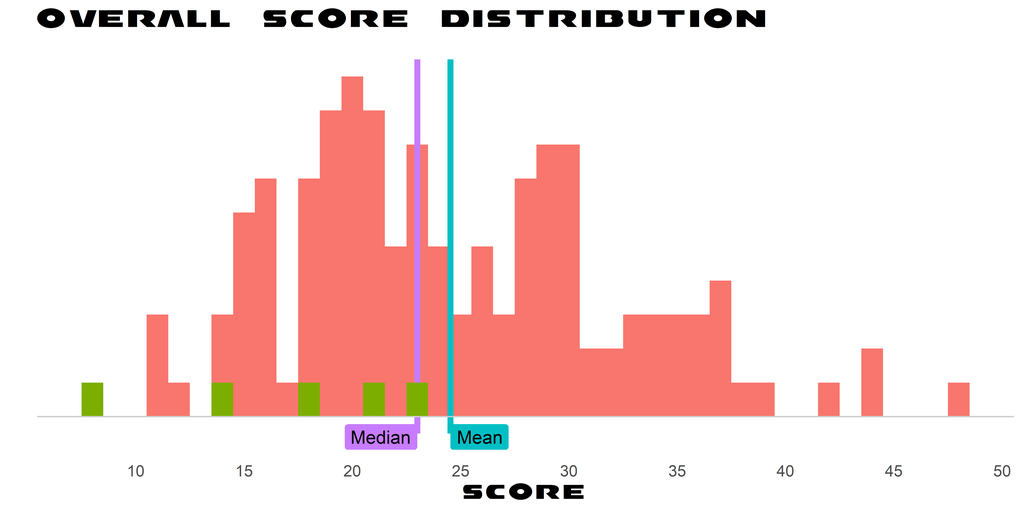

# Round Data

This section depicts the round-level data which contains information on scores in specific maps. Due to difficulty, it may be recorded less frequently than game-level data. The table below shows all recorded rounds.

| Date | Game | Round | Map | Chuck | Neil | Shawn | Steve | Shot | date_dummy |
| --- | --- | --- | --- | --- | --- | --- | --- | --- | --- |
| Monday, March 16, 2020 | 1 | 1 | Dragon Palace | 6 | 18 |  | 7 |  | 2020-03-16 |
| Monday, March 16, 2020 | 1 | 2 | Lunar Colony | 10 | 5 |  | 2 |  | 2020-03-16 |
| Monday, March 16, 2020 | 1 | 3 | Dragon Palace | 4 | 8 |  | 12 |  | 2020-03-16 |
| Monday, March 16, 2020 | 1 | 4 | Luigi's Mansion | 4 | 13 |  | 4 |  | 2020-03-16 |
| Monday, March 16, 2020 | 2 | 1 | Battle Course 1 | 6 | 2 |  | 10 |  | 2020-03-16 |
| Monday, March 16, 2020 | 2 | 2 | Lunar Colony | 7 | 14 |  | 2 |  | 2020-03-16 |
| Monday, March 16, 2020 | 2 | 3 | Battle Stadium | 5 | 10 |  | 2 |  | 2020-03-16 |
| Monday, March 16, 2020 | 2 | 4 | Urchin Underpass | 3 | 5 |  | 4 |  | 2020-03-16 |
| Monday, March 16, 2020 | 3 | 1 | Luigi's Mansion | 5 | 11 |  | 6 |  | 2020-03-16 |
| Monday, March 16, 2020 | 3 | 2 | Lunar Colony | 8 | 9 |  | 4 |  | 2020-03-16 |

[output cut: 98 more lines]

The next table displays average scores for each player on each course.

| Map | Chuck | Neil | Shawn | Steve |
| --- | --- | --- | --- | --- |
| Urchin Underpass | 4.3 | 5.4 | 4.6 | 2.3 |
| Sweet Sweet Kingdom | 4.5 | 5.2 | 4.7 | 6 |
| Luigi's Mansion | 5.2 | 6.7 | 4.7 | 3.6 |
| Wuhu Town | 4.8 | 7 | 4.1 | 5 |
| Lunar Colony | 6 | 8 | 4.8 | 3.5 |
| Battle Stadium | 5.5 | 8.2 | 6.2 | 4 |
| Battle Course 1 | 5 | 6.7 | 8 | 7 |
| Dragon Palace | 6.1 | 9.4 | 6.2 | 5.9 |

The first plot depicts scores over rounds across all nights. That is, the first round of the second match is treated as round 5. Points are jittered for visibility.

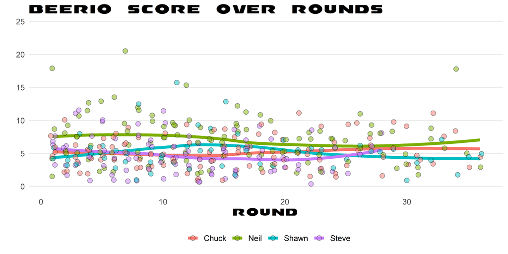

The next plot facets the above information into separate days. The lines will be somewhat over-fit as individuals only have one data point per round.

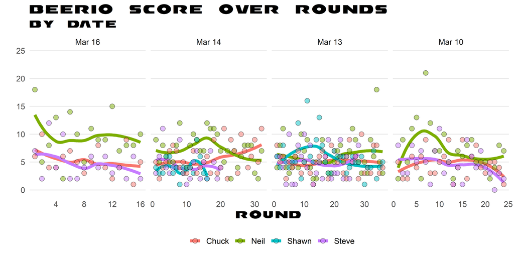

The next plot shows the full distribution of scores for each map colored by player. Courses are sorted by their overall mean score–the map with the current highest mean score is Dragon Palace.

[figure not shown]

The next plot shows differences between each player’s overall average score and their average for the given course. For example, the plot indicates the difference between Neil’s overall average and his Sweet Sweet Kingdom average is -1.9.

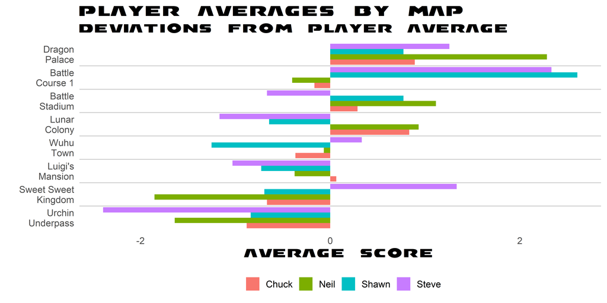

This plot provides an alternate visualization of the same information.

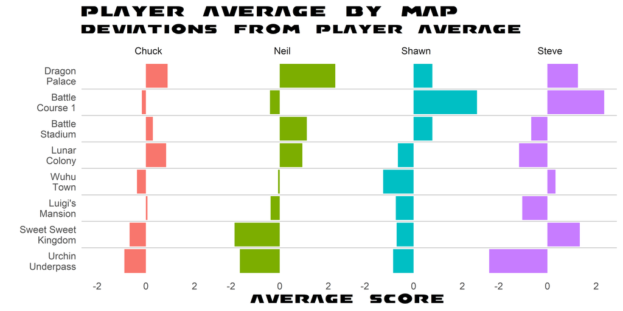